# Machine Learning - Classification of Exercises

cbcoursera1

Saturday, July 11, 2015

# Objective

Build a model from a series of gyroscope and accelerometer measurements which predicts the manner in which a subject performed an exercise.

# The Data

The data for this project is contributed from a study of human motion during exercise, as measured by a variety of gyroscopic and accelerometers attached to several subjects. The data is delivered in a training set (for building the model) and a testing set (for evaluating the model’s accuracy).

Measurements were taken over time, and presented as points-in-time, as summaries of “windows” of time that were relevant for the original experiment, and as calculations done on those windows. Only the first of these three types of data will be valuable for our analysis, so the others were dropped.

Additionally time-series information was removed, because we are considering only point-in-time. Subject names were also removed to ensure that the model would be extrapolatable to a broader population and would not be over influenced by each subjects’ own particular way of movement.

The training data was separated into two groups - a training group representing 60% of observations, and a validation group representing 40% of observations.

The data on its own isn’t particularly significant to explore. It’s composed of obscure observations that are best addresed by a algorithm.

# Building The Model

RandomForest was considered first, as it is particularly relevant for categorical prediction and generally considered a strong method.

A RandomForest model was built with crossvalidation via resampling, resulting in a very tidly accurate model.

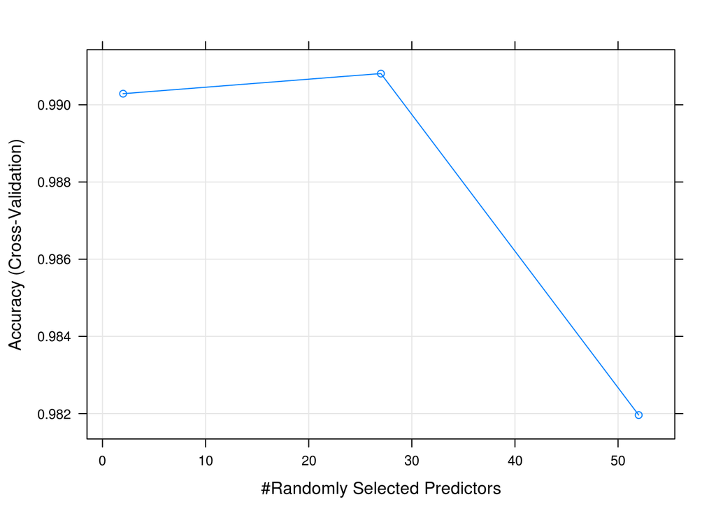

```
## Random Forest
##
## 11532 samples
##    52 predictors
##     5 classes: 'A', 'B', 'C', 'D', 'E'
##
## No pre-processing
## Resampling: Cross-Validated (10 fold)
## Summary of sample sizes: 10379, 10379, 10378, 10379, 10378, 10379, ...
## Resampling results across tuning parameters:
##
##   mtry  Accuracy   Kappa      Accuracy SD  Kappa SD
##    2    0.9902871  0.9877105  0.003560486  0.004506108
##   27    0.9908078  0.9883706  0.002528140  0.003199098
##   52    0.9819625  0.9771776  0.003294521  0.004172925
##
## Accuracy was used to select the optimal model using  the largest value.
## The final value used for the model was mtry = 27.
```

Resampling showed a high degree of accuracy within the training set, with optimal accuracy achieved when utilizing 27 of the 52 predictors.

Comparing against the validation set, there was also a high degree of accuracy:

```
## Confusion Matrix and Statistics
##
##           Reference
## Prediction    A    B    C    D    E
##          A 2185    1    2    0    0
##          B    9 1473    4    1    0
##          C    0   10 1327    3    0
##          D    0    0   15 1243    0
##          E    0    0    8    7 1396
##
## Overall Statistics
##
##                Accuracy : 0.9922
##                  95% CI : (0.99, 0.994)
##     No Information Rate : 0.2855
##     P-Value [Acc > NIR] : < 2.2e-16
##
##                   Kappa : 0.9901
##  Mcnemar's Test P-Value : NA
##
## Statistics by Class:
##
##                      Class: A Class: B Class: C Class: D Class: E
## Sensitivity            0.9959   0.9926   0.9786   0.9912   1.0000
## Specificity            0.9995   0.9977   0.9979   0.9977   0.9976
## Pos Pred Value         0.9986   0.9906   0.9903   0.9881   0.9894
## Neg Pred Value         0.9984   0.9982   0.9954   0.9983   1.0000
## Prevalence             0.2855   0.1931   0.1765   0.1632   0.1817
## Detection Rate         0.2844   0.1917   0.1727   0.1618   0.1817
## Detection Prevalence   0.2847   0.1935   0.1744   0.1637   0.1836
## Balanced Accuracy      0.9977   0.9952   0.9883   0.9944   0.9988
```

0.99 accuracy in crossvalidation when building the model matches 0.99 accuracy when using a confusionMatrix to compare against the validation set. This indicates that the model is extremely accurate and not overfitted.

# Outcome

In the end, the model correctly predicted 100% of the testing data - success.

# APPENDIX

Citation:

Velloso, E.; Bulling, A.; Gellersen, H.; Ugulino, W.; Fuks, H. Qualitative Activity Recognition of Weight Lifting Exercises. Proceedings of 4th International Conference in Cooperation with SIGCHI (Augmented Human ’13) . Stuttgart, Germany: ACM SIGCHI, 2013.

Read more: http://groupware.les.inf.puc-rio.br/har#dataset#ixzz3fcXZS8WB